# IMR Pretest Fall 19 Calibration #1 & #2

12/5/2019

On this page, you will find the following:

1. IMR (interpreting mathematical results) Construct Map,
2. Items & Scoring Guides,
3. WrightMaps,
4. Thresfold Estimates,
5. A link to Item Analysis (from ConQuest), and
6. A link to [StandardsMaps](http://standardsmaps.com:3838/smap/) software (for standards setting).

### [1. IMR Construct Map](https://nmsi.bear-apps.com/constructs/public/fUft37Rtk3i21xShtnnOf6gJRM4CQR)

- PDF of Construct Map, Items, and Scoring Guides is [here](https://drive.google.com/open?id=10rKmoXhOzdaM8wFAab_11a6PFIP7HTBS)

### 2. IMR Items & Scoring Guides on BASS

- [Airline.03a](https://nmsi.bear-apps.com/scheduled_activities/308/activities/344/bundle/388/assignments/5342/score) (L3 is the most difficult; item stem needs to be changed to prompt desired responses)
- [Crude.06ab](https://nmsi.bear-apps.com/scheduled_activities/308/activities/259/item/5328/assignments/score) (prompt should be improved to make students focus on decreasing trends)
- [Cycle.04ab](https://nmsi.bear-apps.com/scheduled_activities/308/activities/264/bundle/360/assignments/5741/score) (Scroll down to the last 2 questions; L1 & L2 not much separation)
- [Garden5abc](https://nmsi.bear-apps.com/scheduled_activities/308/activities/340/item/5769/assignments/5482/score) (Scroll down to the last 3 questions; initially 5a was too difficult as L1 and no L2 vs L3 distinction in 5bc)
- [Hiring 3ab](https://nmsi.bear-apps.com/scheduled_activities/294/activities/346/item/5607/score) (L1, L2, L3 no separation)
- [Pest.05ab](https://nmsi.bear-apps.com/scheduled_activities/308/activities/259/bundle/313/assignments/5219/score) (scroll down to middle; L1 & L2 not much separation)
- [Population.07a](https://nmsi.bear-apps.com/scheduled_activities/308/activities/261/bundle/356/assignments/5119/score) (scroll down to the bottom)
- [Powder.06a](https://nmsi.bear-apps.com/scheduled_activities/308/activities/340/bundle/385/assignments/5482/score) (scroll down to the bottom)
- [Wildlife.02_OE](https://nmsi.bear-apps.com/scheduled_activities/308/activities/261/item/5349/assignments/score) (L1 too easy; only 2 people scored into 0)
- [Word.03_MC](https://nmsi.bear-apps.com/scheduled_activities/308/activities/259/bundle/354/assignments/5219/score) (L1 too easy; only 2 people scored into 0)

### 3a. Initial WrightMaps (from Calibration 1)

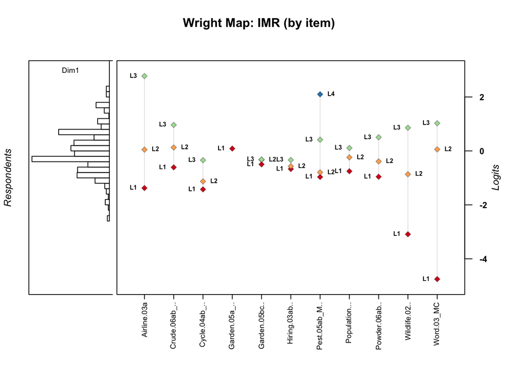

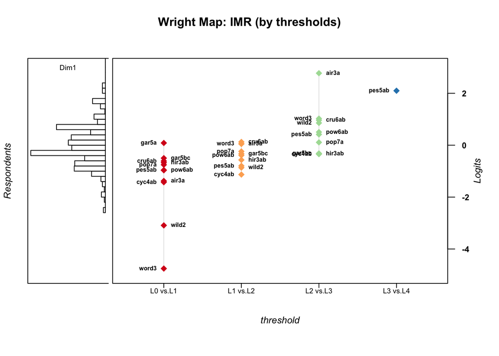

### 3b. WrightMap after Item Investigations (from Calibration 2)

- Reduced overlap between L1 and L2 by making Garden 5a’s thresfold to be L3 (initially it was misplaced at L1)
- Reduced overlap between L2 and L3 by getting rid of partial credits in Garden 5bc & Hiring3ab
- Cycle4ab has some issues with scoring guides (no separation between L1 and L2).A similar issue may exist with Pest5ab.
- The first threshold for Wild2 and Word3 (both very low) should probably be ignored as they are based on only two people scoring into 0.

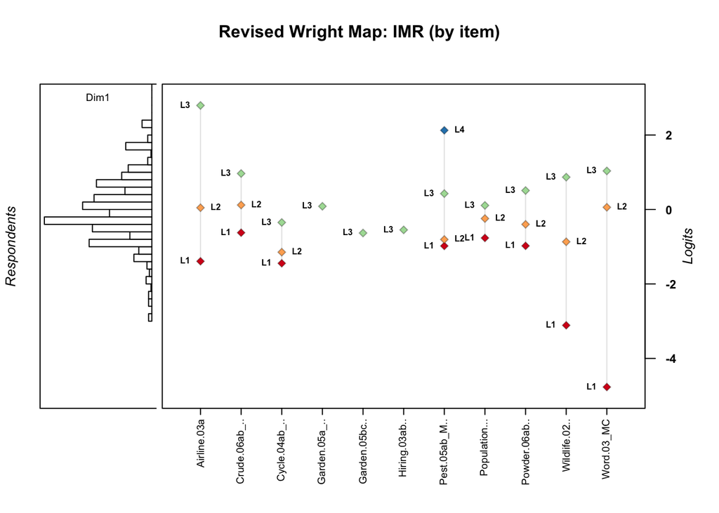

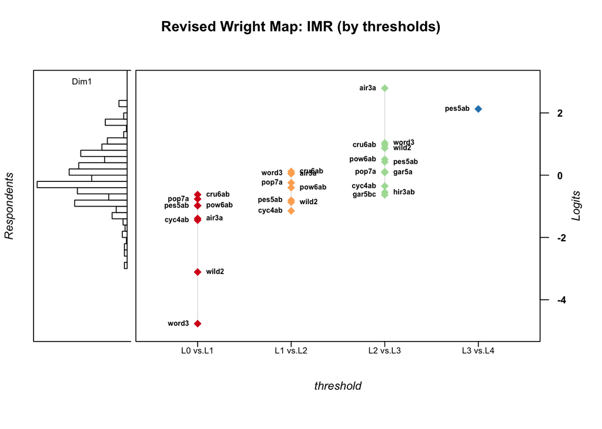

##### Calibration stats from calibration run #2

- 808 cases
- 11 scorable “units”
- WLE Separation Reliability: 0.192 (run#1: 0.167)
- EAP/PV Reliability: 0.355 (run#1: 0.378)
- Weighted MNSQ: 0.91 - 1.07 (run#1: 1.90-1.14)

### 4. Threshold difficulty estimates (from Calibration 2)

| name | L1 | L2 | L3 | L4 |
| --- | --- | --- | --- | --- |
| Airline.03a | -1.39 | 0.05 | 2.79 | NA |
| Crude.06ab_OEOE | -0.62 | 0.12 | 0.97 | NA |
| Cycle.04ab_MCOE | -1.45 | -1.15 | -0.35 | NA |
| Garden.05a_MC | NA | NA | 0.09 | NA |
| Garden.05bc_OE | NA | NA | -0.63 | NA |
| Hiring.03ab_MCOE | NA | NA | -0.55 | NA |
| Pest.05ab_MCOE | -0.98 | -0.81 | 0.43 | 2.13 |
| Population.07a_OE | -0.76 | -0.24 | 0.11 | NA |
| Powder.06ab_MCOE | -0.98 | -0.40 | 0.51 | NA |
| Wildlife.02_OE | -3.11 | -0.87 | 0.87 | NA |
| Word.03_MC | -4.77 | 0.06 | 1.04 | NA |

### 5. Item Analysis (from Calibration 2)

- [Link to Item Analysis](https://drive.google.com/open?id=1yjXX3IIb4Mwysgn6B1t_pq4nOL1b_u7K) (ConQuest output from Run #2 after revisions)

### 6. StandardsMaps Software

- [Link to StandardsMaps](http://standardsmaps.com:3838/smap/) software (for standards setting)
- You need to download [NMSI-IMR.rdata](https://drive.google.com/file/d/1CQwvoDIQNjjj1IFt02M_25nxkxVZjumM/view?usp=sharing) to your machine and upload it to StandardsMaps.
- [Instruction](https://drive.google.com/open?id=1apjNDvdnZY5Y-dAP0W1db4d8BAcUBfJU) for setting up StandardsMaps on your machine.